# Building R Packages

## What are R Packages?

## R Packages

1. Sets of Functions
2. Set of Functions + Documentation
3. Set of Functions + Documentation + Data
4. Set of Functions + Documentation + Data + Vignettes
5. Set of Functions + Documentation + Data + Vignettes + Versions
6. Set of Functions + Documentation + Data + Vignettes + Versions + Dependencies

## Starting Up

Use RStudio and the `devtools` package. It's easier.

```r
install.packages("devtools")
```

In RStudio, File -> New Project -> New Directory -> R Package, with a name:

- must start with letter
- no underscores
- periods allowable or use CamelCase
- can have numbers

## Setting Up

Go to Build -> Configure Build Tools

Add `--as-cran` to "Check Package" (useful later)

[figure not shown]

## Setting Up

Click Generate documents with Roxygen. If that is gray, install `roxygen2`:

```r
install.packages("roxygen2")
```

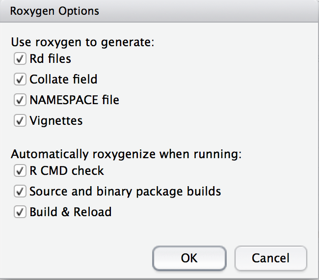

Click "Configure" - click all the boxes.

## Configuring the Setup

- Delete the `man` folder
- `roxygen2` will create the documentation automatically
- Delete NAMESPACE file (we will discuss later)
- `roxygen2` will create the documentation automatically

## DESCRIPTION file

In the RStudio project, go to "Go to file/function" search bar on the menu bar.

- This searches through the files in the package.
- Also searches for **function names** and can go to that function in the file

Type "DESCRIPTION" and open that file.

## DESCRIPTION file

- "Title - What the Package Does (Title Case)
- "Author: YOURNAME"
- "Maintainer: YOURNAME your@email.com"
- "Description: Use paragraph prose here. Don't start with word package" Use four spaces when indenting paragraphs within the Description.
- "License: ", one of GPL-2 GPL-3 LGPL-2 LGPL-2.1 LGPL-3 AGPL-3 Artistic-2.0 BSD_2_clause BSD_3_clause MIT

## DESCRIPTION file: additional fields

- Imports: package1, package2
- packages with specific functions called in package
- Depends: package3, package5
- packages with **ALL** functions loaded from package
- Suggests: package4, package6
- used in **examples** or **vignettes**

## Roxygen2

Roxygen allows for functions and documentation in the same file. Let's make a function:

```r
top = function(x, n) {
  xx = x[1:n, 1:n]
  hist(xx)
  print(xx)
}
```

Save this to `top.R` file in `R/` (where R functions are). Delete `hello.R` file.

## Roxygen2

Highlight the following code:

```r
top = function(x, n) {
```

Go to Code -> Insert Roxygen Skeleton

## Roxygen Skeleton:

Output:

```
#' Title
#'
#' @param x
#' @param n
#'
#' @return
#' @export
#'
#' @examples
```

## Roxygen Skeleton:

Add `@title` and `@description` tags:

```
#' @title
#' @description
#'
#' @param x
#' @param n
#'
#' @return
#' @export
#'
#' @examples
```

## Roxygen Skeleton:

- `@param` stands for a parameter/argument for that function.
- `@return` denotes what the function returns. This is required.
- `@export` - when people install your package, can they use this function
- non-exported functions are usually helpers, really small, or not fully formed yet
- `@examples` - code to show how the function works. Wrap functions in `\dontrun{}` if not wanted to run

## Roxygen Skeleton:

[output not shown]

## NAMESPACE

The `NAMESPACE` files tells the R package what to import and export. In Roxygen:

- `@export` - adds this to the NAMESPACE file
- when package is installed, users can call this function
- `@import` - in roxygen, if you want to import a **package**, you say `@import PACKAGENAME`
- imports **ALL** functions from that package
- if package is listed under Depends in DESCRIPTION, then the **whole package** is loaded when you load your package
- otherwise it simply exposes them for your package to use them, but not the user, users still have to do `library(PACKAGENAME)`

## NAMESPACE

- `@importFrom` - in roxygen, if you want to import a **function**, you say `@import PACKAGENAME func1 func2`
- only imports these functions. Better way of doing things.
- if `pkgA` has function `A` and `pkgB` has functions `A` and `B`, if `@import pkgA A`, `@import pkgB B`, then if you call `A()`, R knows it's from `pkgA`
- you must import anything explicitly other than from the `base` package, includying anything from `stats` (e.g. `quantile`) or `graphics` (e.g. `hist`)

Add `@importFrom graphics hist` to your top.R file

## Build and Reload

- Go to Build -> Build and Reload the package
  - First time you may see some warnings (no NAMESPACE file!)
  - Rerunning should get rid of these
  - look in the folders
- Then try Build -> Check Package